# Análise Exploratória - Ciclismo de Rua

Marcela Ruela

2025-06-26

**1. INSTALAÇÃO E CARREGAMENTO DE PACOTES NECESSÁRIOS**

```r
pacotes <- c("plotly","tidyverse","ggrepel","fastDummies","knitr","kableExtra",
             "splines","reshape2","PerformanceAnalytics","metan","correlation",
             "see","ggraph","nortest","rgl","car","olsrr","jtools","ggstance",
             "magick","cowplot","beepr","Rcpp","readxl", "cluster", "fpc","factoextra",
             "ggpubr",'lubridate','lpSolve', 'caret', "patchwork", "zoo")

if(sum(as.numeric(!pacotes %in% installed.packages())) != 0){
  instalador <- pacotes[!pacotes %in% installed.packages()]
  for(i in 1:length(instalador)) {
    install.packages(instalador, dependencies = T)
    break()}
  sapply(pacotes, require, character = T)
} else {
  sapply(pacotes, require, character = T)
}
```

[output not shown]

```
##               plotly            tidyverse              ggrepel
##                 TRUE                 TRUE                 TRUE
##          fastDummies                knitr           kableExtra
##                 TRUE                 TRUE                 TRUE
##              splines             reshape2 PerformanceAnalytics
##                 TRUE                 TRUE                 TRUE
##                metan          correlation                  see
##                 TRUE                 TRUE                 TRUE
##               ggraph              nortest                  rgl
##                 TRUE                 TRUE                FALSE
##                  car                olsrr               jtools
##                 TRUE                 TRUE                 TRUE
##             ggstance               magick              cowplot
##                 TRUE                 TRUE                 TRUE
##                beepr                 Rcpp               readxl
##                 TRUE                 TRUE                 TRUE
##              cluster                  fpc           factoextra
##                 TRUE                 TRUE                 TRUE
##               ggpubr            lubridate              lpSolve
##                 TRUE                 TRUE                 TRUE
##                caret            patchwork                  zoo
##                 TRUE                 TRUE                 TRUE
```

**2. DATA WRAGLING**

- 2.1 Carregamento dos dados
1. Período FTP = 156W

```r
dados1 <- read_excel('Atividades.xlsx', sheet = 'Planilha1')

# Visualização do dataset e formato das variáveis
dados1 %>% head()
```

```
## # A tibble: 6 × 10
##   Data                distancia calorias tempo               fc_med fc_max
##   <dttm>                  <dbl>    <dbl> <dttm>               <dbl>  <dbl>
## 1 2022-03-03 06:45:00      39.7      936 1899-12-31 01:31:52    176    195
## 2 2022-03-02 07:08:00      32.2      940 1899-12-31 01:29:24    177    201
## 3 2022-02-27 06:06:00      14.3      730 1899-12-31 01:13:59    169    194
## 4 2022-02-24 04:26:00      37.8      738 1899-12-31 01:20:38    154    190
## 5 2022-02-23 04:26:00      32.9      730 1899-12-31 01:07:57    175    191
## 6 2022-02-22 04:28:00      33.9      693 1899-12-31 01:24:26    147    164
## # ℹ 4 more variables: training_effect_aerobic <dbl>, v_med <dbl>, v_max <dbl>,
## #   elevacao <dbl>
```

```r
# Resumo das estatísticas descritivas
summary(dados1)
```

```
##       Data                          distancia         calorias
##  Min.   :2021-06-20 05:47:00.00   Min.   : 14.31   Min.   : 536
##  1st Qu.:2021-08-17 03:56:00.00   1st Qu.: 37.93   1st Qu.: 719
##  Median :2021-10-23 06:14:00.00   Median : 41.91   Median : 825
##  Mean   :2021-10-23 11:43:48.71   Mean   : 56.65   Mean   :1049
##  3rd Qu.:2021-12-29 03:59:00.00   3rd Qu.: 57.62   3rd Qu.:1036
##  Max.   :2022-03-03 06:45:00.00   Max.   :209.17   Max.   :4141
##      tempo                            fc_med          fc_max
##  Min.   :1899-12-31 01:07:57.00   Min.   :139.0   Min.   :159
##  1st Qu.:1899-12-31 01:32:28.00   1st Qu.:153.0   1st Qu.:185
##  Median :1899-12-31 01:44:53.00   Median :159.0   Median :189
##  Mean   :1899-12-31 02:19:26.57   Mean   :158.8   Mean   :187
##  3rd Qu.:1899-12-31 02:33:44.00   3rd Qu.:166.0   3rd Qu.:191
##  Max.   :1899-12-31 09:36:01.00   Max.   :177.0   Max.   :201
##  training_effect_aerobic     v_med           v_max          elevacao
##  Min.   :2.400           Min.   :11.60   Min.   :25.60   Min.   :  35.0
##  1st Qu.:3.300           1st Qu.:21.70   1st Qu.:36.10   1st Qu.: 190.0
##  Median :4.000           Median :25.30   Median :38.70   Median : 361.0
##  Mean   :3.917           Mean   :24.37   Mean   :41.58   Mean   : 475.5
##  3rd Qu.:4.500           3rd Qu.:27.00   3rd Qu.:47.60   3rd Qu.: 599.0
##  Max.   :5.000           Max.   :33.30   Max.   :65.00   Max.   :2465.0
```

```r
# Renomear a coluna tempo para tempo_pedal para igualar às outras planilhas
dados1 <- rename(dados1, "tempo_pedal" = "tempo")
head(dados1) #OK!
```

```
## # A tibble: 6 × 10
##   Data                distancia calorias tempo_pedal         fc_med fc_max
##   <dttm>                  <dbl>    <dbl> <dttm>               <dbl>  <dbl>
## 1 2022-03-03 06:45:00      39.7      936 1899-12-31 01:31:52    176    195
## 2 2022-03-02 07:08:00      32.2      940 1899-12-31 01:29:24    177    201
## 3 2022-02-27 06:06:00      14.3      730 1899-12-31 01:13:59    169    194
## 4 2022-02-24 04:26:00      37.8      738 1899-12-31 01:20:38    154    190
## 5 2022-02-23 04:26:00      32.9      730 1899-12-31 01:07:57    175    191
## 6 2022-02-22 04:28:00      33.9      693 1899-12-31 01:24:26    147    164
## # ℹ 4 more variables: training_effect_aerobic <dbl>, v_med <dbl>, v_max <dbl>,
## #   elevacao <dbl>
```

2. Período FTP = 165W

```r
dados2 <- read_excel('Activities_nova.xlsx')

# Visualização do dataset e formato das variáveis
dados2 %>% head()
```

```
## # A tibble: 6 × 11
##   Data                distancia calorias tempo_pedal         fc_med fc_max
##   <dttm>                  <dbl>    <dbl> <dttm>               <dbl>  <dbl>
## 1 2022-05-11 04:28:38      50.8      893 1899-12-31 01:51:52    162    188
## 2 2022-05-10 04:26:35      31.4      564 1899-12-31 01:13:32    150    192
## 3 2022-05-08 07:02:01      42.7     1117 1899-12-31 02:35:39    155    191
## 4 2022-05-07 06:25:25      79.5     1440 1899-12-31 02:56:22    160    195
## 5 2022-05-05 04:27:59      36.2      715 1899-12-31 01:21:43    158    186
## 6 2022-05-01 06:10:39     130.      2450 1899-12-31 04:23:33    174    193
## # ℹ 5 more variables: training_effect_aerobic <dbl>, v_med <dbl>, v_max <dbl>,
## #   elevacao <dbl>, tempo_total <dttm>
```

```r
# Remover última coluna do dataset
dados2 <- dados2[1:10]

# Resumo estatísticas descritivas
summary(dados2)
```

```
##       Data                          distancia         calorias
##  Min.   :2022-03-05 06:19:25.00   Min.   : 25.50   Min.   : 524
##  1st Qu.:2022-04-03 07:02:32.00   1st Qu.: 30.76   1st Qu.: 633
##  Median :2022-04-16 05:33:08.00   Median : 35.45   Median : 736
##  Mean   :2022-04-16 10:14:29.48   Mean   : 47.07   Mean   :1011
##  3rd Qu.:2022-05-01 06:10:39.00   3rd Qu.: 42.66   3rd Qu.:1269
##  Max.   :2022-05-21 06:11:13.00   Max.   :130.40   Max.   :2450
##   tempo_pedal                         fc_med          fc_max
##  Min.   :1899-12-31 01:00:44.00   Min.   :145.0   Min.   :161
##  1st Qu.:1899-12-31 01:13:49.00   1st Qu.:155.0   1st Qu.:186
##  Median :1899-12-31 01:23:15.00   Median :161.0   Median :192
##  Mean   :1899-12-31 01:54:41.23   Mean   :160.5   Mean   :187
##  3rd Qu.:1899-12-31 02:35:39.00   3rd Qu.:166.0   3rd Qu.:195
##  Max.   :1899-12-31 04:23:33.00   Max.   :176.0   Max.   :203
##  training_effect_aerobic     v_med           v_max          elevacao
##  Min.   :3.100           Min.   :15.60   Min.   :28.70   Min.   :  63.0
##  1st Qu.:3.800           1st Qu.:24.00   1st Qu.:34.70   1st Qu.: 101.0
##  Median :4.300           Median :25.30   Median :38.60   Median : 166.0
##  Mean   :4.286           Mean   :24.39   Mean   :40.62   Mean   : 339.5
##  3rd Qu.:5.000           3rd Qu.:27.00   3rd Qu.:44.90   3rd Qu.: 525.0
##  Max.   :5.000           Max.   :29.70   Max.   :62.40   Max.   :1068.0
```

3. Período FTP = 171W

```r
dados3 <- read_excel('Banco de Dados_Bike.xlsx', sheet = 'Folha 1')
dados3 %>% head()
```

```
## # A tibble: 6 × 11
##   Data       distancia calorias tempo_pedal fc_med fc_max training_effect_aero…¹
##   <chr>          <dbl>    <dbl> <chr>        <dbl>  <dbl>                  <dbl>
## 1 2023-03-1…      43.1     1210 02:06:28       169    189                    5
## 2 2023-03-2…      44.6     1236 02:15:20       164    188                    5
## 3 2023-05-0…      12.1      270 00:46:57       119    146                    1
## 4 2023-05-1…      41.4      816 01:26:43       158    182                    4
## 5 2023-05-2…      47.4     1254 02:27:36       157    184                    4.4
## 6 2023-06-0…      66.8     1136 02:22:46       152    184                    4.3
## # ℹ abbreviated name: ¹training_effect_aerobic
## # ℹ 4 more variables: v_med <dbl>, v_max <dbl>, elevacao <dbl>,
## #   tempo_total <chr>
```

```r
# Remover última coluna para igualar número de colunas de todos datasets

dados3 <- dados3[1:10]

# Tempos e datas como caractére. Necessária transformação para POSIXct
dados3$Data <- as.POSIXct(dados3$Data, format = "%Y-%m-%d %H:%M:%S")
dados3$tempo_pedal <- as.POSIXct(dados3$tempo_pedal, format = "%H:%M:%S")

dados3 %>% head() #OK!
```

```
## # A tibble: 6 × 10
##   Data                distancia calorias tempo_pedal         fc_med fc_max
##   <dttm>                  <dbl>    <dbl> <dttm>               <dbl>  <dbl>
## 1 2023-03-19 07:29:18      43.1     1210 2025-06-26 02:06:28    169    189
## 2 2023-03-26 06:39:18      44.6     1236 2025-06-26 02:15:20    164    188
## 3 2023-05-01 09:43:24      12.1      270 2025-06-26 00:46:57    119    146
## 4 2023-05-14 06:23:37      41.4      816 2025-06-26 01:26:43    158    182
## 5 2023-05-28 07:08:42      47.4     1254 2025-06-26 02:27:36    157    184
## 6 2023-06-04 06:43:54      66.8     1136 2025-06-26 02:22:46    152    184
## # ℹ 4 more variables: training_effect_aerobic <dbl>, v_med <dbl>, v_max <dbl>,
## #   elevacao <dbl>
```

```r
# Visualizando as estatísticas descritivas
summary(dados3)
```

```
##       Data                          distancia        calorias
##  Min.   :2023-03-19 07:29:18.00   Min.   :12.06   Min.   : 270
##  1st Qu.:2023-05-01 09:43:24.00   1st Qu.:43.09   1st Qu.:1136
##  Median :2023-05-28 07:08:42.00   Median :47.44   Median :1210
##  Mean   :2023-05-22 02:01:08.77   Mean   :49.93   Mean   :1101
##  3rd Qu.:2023-06-18 06:52:41.00   3rd Qu.:66.79   3rd Qu.:1254
##  Max.   :2023-07-16 08:10:07.00   Max.   :72.52   Max.   :1443
##   tempo_pedal                         fc_med          fc_max
##  Min.   :2025-06-26 00:46:57.00   Min.   :119.0   Min.   :146.0
##  1st Qu.:2025-06-26 02:06:28.00   1st Qu.:153.0   1st Qu.:182.0
##  Median :2025-06-26 02:17:58.00   Median :156.0   Median :184.0
##  Mean   :2025-06-26 02:05:48.10   Mean   :153.8   Mean   :180.7
##  3rd Qu.:2025-06-26 02:27:36.00   3rd Qu.:158.0   3rd Qu.:186.0
##  Max.   :2025-06-26 02:34:22.00   Max.   :169.0   Max.   :189.0
##  training_effect_aerobic     v_med           v_max          elevacao
##  Min.   :1.0             Min.   :15.40   Min.   :30.50   Min.   : 85.0
##  1st Qu.:4.1             1st Qu.:19.80   1st Qu.:34.90   1st Qu.:345.0
##  Median :4.4             Median :21.30   Median :37.20   Median :461.0
##  Mean   :4.1             Mean   :23.27   Mean   :40.68   Mean   :480.1
##  3rd Qu.:4.7             3rd Qu.:28.20   3rd Qu.:47.40   3rd Qu.:709.0
##  Max.   :5.0             Max.   :28.70   Max.   :53.00   Max.   :817.0
```

```r
# Ressalva: poucas observações
```

4. Período 182W: mesmo passo a passo do que item 3 (mesmos formatos de variáveis)

```r
dados4 <- read_excel('Banco de Dados_Bike.xlsx', sheet = 'Folha 2')
dados4 %>% head()
```

```
## # A tibble: 6 × 11
##   Data       distancia calorias tempo_pedal fc_med fc_max training_effect_aero…¹
##   <chr>          <dbl>    <dbl> <chr>        <dbl>  <dbl>                  <dbl>
## 1 2023-08-0…      60.0     1293 01:58:53       164    183                    5
## 2 2023-09-1…      42.6     1062 02:00:37       149    173                    3.9
## 3 2023-10-1…      27.3      945 01:27:17       167    190                    5
## 4 2023-10-2…      30.0      938 01:30:40       159    187                    4.3
## 5 2023-10-2…      29.8     1150 01:49:17       166    185                    5
## 6 2023-12-0…      20.2      494 00:40:38       180    184                    5
## # ℹ abbreviated name: ¹training_effect_aerobic
## # ℹ 4 more variables: v_med <dbl>, v_max <dbl>, elevacao <dbl>,
## #   tempo_total <chr>
```

```r
# Remover última coluna para igualar número de colunas de todos datasets

dados4 <- dados4[1:10]

# Tempos e datas como caractére. Necessária transformação para POSIXct
dados4$Data <- as.POSIXct(dados4$Data, format = "%Y-%m-%d %H:%M:%S")
dados4$tempo_pedal <- as.POSIXct(dados4$tempo_pedal, format = "%H:%M:%S")

dados4 %>% head() #OK!
```

```
## # A tibble: 6 × 10
##   Data                distancia calorias tempo_pedal         fc_med fc_max
##   <dttm>                  <dbl>    <dbl> <dttm>               <dbl>  <dbl>
## 1 2023-08-05 07:05:18      60.0     1293 2025-06-26 01:58:53    164    183
## 2 2023-09-16 06:11:41      42.6     1062 2025-06-26 02:00:37    149    173
## 3 2023-10-18 08:26:05      27.3      945 2025-06-26 01:27:17    167    190
## 4 2023-10-24 05:59:12      30.0      938 2025-06-26 01:30:40    159    187
## 5 2023-10-25 06:57:51      29.8     1150 2025-06-26 01:49:17    166    185
## 6 2023-12-02 07:03:14      20.2      494 2025-06-26 00:40:38    180    184
## # ℹ 4 more variables: training_effect_aerobic <dbl>, v_med <dbl>, v_max <dbl>,
## #   elevacao <dbl>
```

```r
# Visualizando as estatísticas descritivas
summary(dados4)
```

```
##       Data                          distancia        calorias
##  Min.   :2023-08-05 07:05:18.00   Min.   :10.36   Min.   : 230.0
##  1st Qu.:2023-10-19 19:49:21.75   1st Qu.:21.95   1st Qu.: 605.0
##  Median :2023-11-13 07:00:32.50   Median :29.86   Median :1003.5
##  Mean   :2023-11-19 16:52:32.79   Mean   :34.37   Mean   : 914.8
##  3rd Qu.:2024-01-11 19:10:38.50   3rd Qu.:49.93   3rd Qu.:1202.5
##  Max.   :2024-02-04 08:13:50.00   Max.   :60.76   Max.   :1560.0
##   tempo_pedal                         fc_med          fc_max
##  Min.   :2025-06-26 00:20:51.00   Min.   :149.0   Min.   :173.0
##  1st Qu.:2025-06-26 00:52:17.75   1st Qu.:159.5   1st Qu.:182.2
##  Median :2025-06-26 01:39:58.50   Median :165.0   Median :183.5
##  Mean   :2025-06-26 01:28:50.59   Mean   :163.5   Mean   :183.5
##  3rd Qu.:2025-06-26 02:00:11.00   3rd Qu.:167.0   3rd Qu.:186.5
##  Max.   :2025-06-26 02:29:38.00   Max.   :180.0   Max.   :190.0
##  training_effect_aerobic     v_med           v_max          elevacao
##  Min.   :2.90            Min.   :16.30   Min.   :34.20   Min.   : 12.0
##  1st Qu.:4.00            1st Qu.:20.15   1st Qu.:36.12   1st Qu.:168.5
##  Median :5.00            Median :24.45   Median :42.35   Median :452.0
##  Mean   :4.45            Mean   :24.30   Mean   :42.84   Mean   :378.0
##  3rd Qu.:5.00            3rd Qu.:29.38   3rd Qu.:47.70   3rd Qu.:481.2
##  Max.   :5.00            Max.   :30.30   Max.   :54.60   Max.   :852.0
```

```r
# Ressalva: poucas observações
```

5. Período 173W: mesmo passo a passo do que item 3 (mesmos formatos de variáveis)

```r
dados5 <- read_excel('Banco de Dados_Bike.xlsx', sheet = 'Folha 3')
dados5 %>% head()
```

```
## # A tibble: 6 × 11
##   Data       distancia calorias tempo_pedal fc_med fc_max training_effect_aero…¹
##   <chr>          <dbl>    <dbl> <chr>        <dbl>  <dbl>                  <dbl>
## 1 2024-04-1…      47.1     1071 01:48:14       161    185                    5
## 2 2024-04-2…      50.0     1112 02:02:48       160    179                    4.9
## 3 2024-06-0…      65.2     1230 02:44:39       138    175                    3.4
## 4 2024-06-0…      68.8     1421 02:40:03       150    177                    4.3
## 5 2024-07-1…      52.2     1110 01:58:55       155    178                    4.4
## 6 2024-07-2…      66.6     1633 02:47:04       159    194                    5
## # ℹ abbreviated name: ¹training_effect_aerobic
## # ℹ 4 more variables: v_med <dbl>, v_max <dbl>, elevacao <dbl>,
## #   tempo_total <chr>
```

```r
# Remover última coluna para igualar número de colunas de todos datasets

dados5 <- dados5[1:10]

# Tempos e datas como caractére. Necessária transformação para POSIXct
dados5$Data <- as.POSIXct(dados5$Data, format = "%Y-%m-%d %H:%M:%S")
dados5$tempo_pedal <- as.POSIXct(dados5$tempo_pedal, format = "%H:%M:%S")

dados5 %>% head() #OK!
```

```
## # A tibble: 6 × 10
##   Data                distancia calorias tempo_pedal         fc_med fc_max
##   <dttm>                  <dbl>    <dbl> <dttm>               <dbl>  <dbl>
## 1 2024-04-14 07:22:05      47.1     1071 2025-06-26 01:48:14    161    185
## 2 2024-04-26 06:11:39      50.0     1112 2025-06-26 02:02:48    160    179
## 3 2024-06-02 07:11:20      65.2     1230 2025-06-26 02:44:39    138    175
## 4 2024-06-08 06:46:05      68.8     1421 2025-06-26 02:40:03    150    177
## 5 2024-07-13 08:27:07      52.2     1110 2025-06-26 01:58:55    155    178
## 6 2024-07-20 08:19:12      66.6     1633 2025-06-26 02:47:04    159    194
## # ℹ 4 more variables: training_effect_aerobic <dbl>, v_med <dbl>, v_max <dbl>,
## #   elevacao <dbl>
```

```r
# Visualizando as estatísticas descritivas
summary(dados5)
```

```
##       Data                          distancia        calorias
##  Min.   :2024-04-14 07:22:05.00   Min.   :22.48   Min.   : 554
##  1st Qu.:2024-06-06 18:52:23.75   1st Qu.:51.67   1st Qu.:1112
##  Median :2024-07-24 08:29:52.00   Median :60.31   Median :1216
##  Mean   :2024-07-21 17:23:52.25   Mean   :60.09   Mean   :1357
##  3rd Qu.:2024-08-26 01:10:46.75   3rd Qu.:68.93   3rd Qu.:1630
##  Max.   :2024-10-26 08:12:36.00   Max.   :91.52   Max.   :2218
##   tempo_pedal                         fc_med          fc_max
##  Min.   :2025-06-26 00:50:34.00   Min.   :138.0   Min.   :175.0
##  1st Qu.:2025-06-26 01:58:54.50   1st Qu.:153.8   1st Qu.:177.8
##  Median :2025-06-26 02:25:49.00   Median :159.5   Median :185.0
##  Mean   :2025-06-26 02:22:59.32   Mean   :157.2   Mean   :182.5
##  3rd Qu.:2025-06-26 02:45:15.25   3rd Qu.:162.8   3rd Qu.:185.0
##  Max.   :2025-06-26 03:26:35.00   Max.   :167.0   Max.   :194.0
##  training_effect_aerobic     v_med           v_max          elevacao
##  Min.   :3.400           Min.   :23.30   Min.   :41.60   Min.   : 255.0
##  1st Qu.:4.275           1st Qu.:24.27   1st Qu.:45.48   1st Qu.: 483.2
##  Median :4.950           Median :25.95   Median :48.00   Median : 647.5
##  Mean   :4.600           Mean   :25.38   Mean   :48.33   Mean   : 677.0
##  3rd Qu.:5.000           3rd Qu.:26.45   3rd Qu.:52.00   3rd Qu.: 806.8
##  Max.   :5.000           Max.   :26.80   Max.   :52.90   Max.   :1107.0
```

```r
# Ressalva: poucas observações
```

6. Período 186W: mesmo passo a passo do que item 3 (mesmos formatos de variáveis)

```r
dados6 <- read_excel('Banco de Dados_Bike.xlsx', sheet = 'Folha 4')
dados6 %>% head()
```

```
## # A tibble: 6 × 11
##   Data       distancia calorias tempo_pedal fc_med fc_max training_effect_aero…¹
##   <chr>          <dbl>    <dbl> <chr>        <dbl>  <dbl>                  <dbl>
## 1 2025-06-2…     34.7      1032 01:42:08       166    195                    5
## 2 2025-06-1…     48.1       843 01:55:28       145    184                    3.6
## 3 2025-06-0…     13.3       527 01:14:45       140    180                    3
## 4 2025-06-0…     20.7       582 01:21:04       140    182                    3
## 5 2025-05-3…      6.82      269 00:38:02       135    188                    2.6
## 6 2025-04-2…     40.4      1039 02:10:09       152    176                    4.2
## # ℹ abbreviated name: ¹training_effect_aerobic
## # ℹ 4 more variables: v_med <dbl>, v_max <dbl>, elevacao <dbl>,
## #   tempo_total <chr>
```

```r
# Remover última coluna para igualar número de colunas de todos datasets
dados6 <- dados6[1:10]

# Tempos e datas como caractére. Necessária transformação para POSIXct
dados6$Data <- as.POSIXct(dados6$Data, format = "%Y-%m-%d %H:%M:%S")
dados6$tempo_pedal <- as.POSIXct(dados6$tempo_pedal, format = "%H:%M:%S")

dados6 %>% head() #OK!
```

```
## # A tibble: 6 × 10
##   Data                distancia calorias tempo_pedal         fc_med fc_max
##   <dttm>                  <dbl>    <dbl> <dttm>               <dbl>  <dbl>
## 1 2025-06-20 07:56:49     34.7      1032 2025-06-26 01:42:08    166    195
## 2 2025-06-15 07:43:45     48.1       843 2025-06-26 01:55:28    145    184
## 3 2025-06-08 10:46:37     13.3       527 2025-06-26 01:14:45    140    180
## 4 2025-06-01 07:44:17     20.7       582 2025-06-26 01:21:04    140    182
## 5 2025-05-31 10:59:25      6.82      269 2025-06-26 00:38:02    135    188
## 6 2025-04-20 07:19:03     40.4      1039 2025-06-26 02:10:09    152    176
## # ℹ 4 more variables: training_effect_aerobic <dbl>, v_med <dbl>, v_max <dbl>,
## #   elevacao <dbl>
```

```r
# Visualizando as estatísticas descritivas
summary(dados6)
```

```
##       Data                          distancia        calorias
##  Min.   :2024-11-02 06:10:23.00   Min.   : 6.82   Min.   : 269.0
##  1st Qu.:2025-01-20 17:55:40.25   1st Qu.:36.10   1st Qu.: 890.2
##  Median :2025-02-25 19:52:09.50   Median :53.00   Median :1130.0
##  Mean   :2025-03-09 04:44:12.27   Mean   :50.71   Mean   :1173.4
##  3rd Qu.:2025-05-21 04:04:19.50   3rd Qu.:66.62   3rd Qu.:1514.5
##  Max.   :2025-06-20 07:56:49.00   Max.   :91.56   Max.   :2035.0
##   tempo_pedal                         fc_med          fc_max
##  Min.   :2025-06-26 00:38:02.00   Min.   :135.0   Min.   :176.0
##  1st Qu.:2025-06-26 01:45:28.00   1st Qu.:146.8   1st Qu.:182.0
##  Median :2025-06-26 02:07:23.00   Median :156.0   Median :184.0
##  Mean   :2025-06-26 02:14:53.10   Mean   :154.0   Mean   :184.6
##  3rd Qu.:2025-06-26 02:56:26.00   3rd Qu.:158.0   3rd Qu.:187.8
##  Max.   :2025-06-26 03:52:02.00   Max.   :180.0   Max.   :195.0
##  training_effect_aerobic     v_med           v_max          elevacao
##  Min.   :2.600           Min.   :10.70   Min.   :30.60   Min.   : 132.0
##  1st Qu.:4.050           1st Qu.:19.57   1st Qu.:45.30   1st Qu.: 566.2
##  Median :4.500           Median :23.65   Median :51.35   Median : 710.0
##  Mean   :4.289           Mean   :21.76   Mean   :49.33   Mean   : 734.8
##  3rd Qu.:4.900           3rd Qu.:25.07   3rd Qu.:52.70   3rd Qu.:1000.2
##  Max.   :5.000           Max.   :28.70   Max.   :59.10   Max.   :1155.0
```

```r
# Ressalva: poucas observações
```

7. Criação de um único dataframe identificando cada periodo de FTP

```r
# Adicionando uma coluna de identificação
dados1$periodo <- "FTP = 156W"
dados2$periodo <- "FTP = 165W"
dados3$periodo <- "FTP = 171W"
dados4$periodo <- "FTP = 182W"
dados5$periodo <- "FTP = 173W"
dados6$periodo <- "FTP = 186W"

# Juntar todos os data.frames
dados_todos <- bind_rows(dados1, dados2, dados3, dados4, dados5, dados6)
dados_todos %>% head()
```

```
## # A tibble: 6 × 11
##   Data                distancia calorias tempo_pedal         fc_med fc_max
##   <dttm>                  <dbl>    <dbl> <dttm>               <dbl>  <dbl>
## 1 2022-03-03 06:45:00      39.7      936 1899-12-31 01:31:52    176    195
## 2 2022-03-02 07:08:00      32.2      940 1899-12-31 01:29:24    177    201
## 3 2022-02-27 06:06:00      14.3      730 1899-12-31 01:13:59    169    194
## 4 2022-02-24 04:26:00      37.8      738 1899-12-31 01:20:38    154    190
## 5 2022-02-23 04:26:00      32.9      730 1899-12-31 01:07:57    175    191
## 6 2022-02-22 04:28:00      33.9      693 1899-12-31 01:24:26    147    164
## # ℹ 5 more variables: training_effect_aerobic <dbl>, v_med <dbl>, v_max <dbl>,
## #   elevacao <dbl>, periodo <chr>
```

```r
#OK! 179 Observações no total

# Visualizando as estatíticas descritivas
summary(dados_todos)
```

```
##       Data                          distancia         calorias
##  Min.   :2021-06-20 05:47:00.00   Min.   :  6.82   Min.   : 230
##  1st Qu.:2021-10-01 05:07:30.00   1st Qu.: 36.15   1st Qu.: 715
##  Median :2022-02-01 03:56:00.00   Median : 42.41   Median : 884
##  Mean   :2022-08-10 06:09:17.49   Mean   : 53.15   Mean   :1071
##  3rd Qu.:2023-05-21 09:46:09.50   3rd Qu.: 60.56   3rd Qu.:1297
##  Max.   :2025-06-20 10:56:49.00   Max.   :209.17   Max.   :4141
##   tempo_pedal                         fc_med          fc_max
##  Min.   :1899-12-31 01:00:44.00   Min.   :119.0   Min.   :146
##  1st Qu.:1899-12-31 01:32:48.00   1st Qu.:153.0   1st Qu.:184
##  Median :1899-12-31 02:13:15.00   Median :159.0   Median :188
##  Mean   :1934-05-08 14:08:40.94   Mean   :158.5   Mean   :186
##  3rd Qu.:2025-06-26 03:43:47.50   3rd Qu.:166.0   3rd Qu.:191
##  Max.   :2025-06-26 06:52:02.00   Max.   :180.0   Max.   :203
##  training_effect_aerobic     v_med           v_max          elevacao
##  Min.   :1.000           Min.   :10.70   Min.   :25.60   Min.   :  12.0
##  1st Qu.:3.500           1st Qu.:21.65   1st Qu.:36.10   1st Qu.: 188.5
##  Median :4.200           Median :25.10   Median :40.50   Median : 470.0
##  Mean   :4.099           Mean   :24.12   Mean   :42.68   Mean   : 487.8
##  3rd Qu.:5.000           3rd Qu.:26.95   3rd Qu.:50.45   3rd Qu.: 645.5
##  Max.   :5.000           Max.   :33.30   Max.   :65.00   Max.   :2465.0
##    periodo
##  Length:179
##  Class :character
##  Mode  :character
##
##
##
```

**2. EXPLORAÇÃO DOS DADOS**

Vamos iniciar a exploração dos dados entendendo melhor a correlação deles entre si. Como o periodo é um caractere, vamos retirá-lo da análise e explorar primenro essas relações do banco de dados como um todo. Além disso, será necessário remover as datas dessa análise.

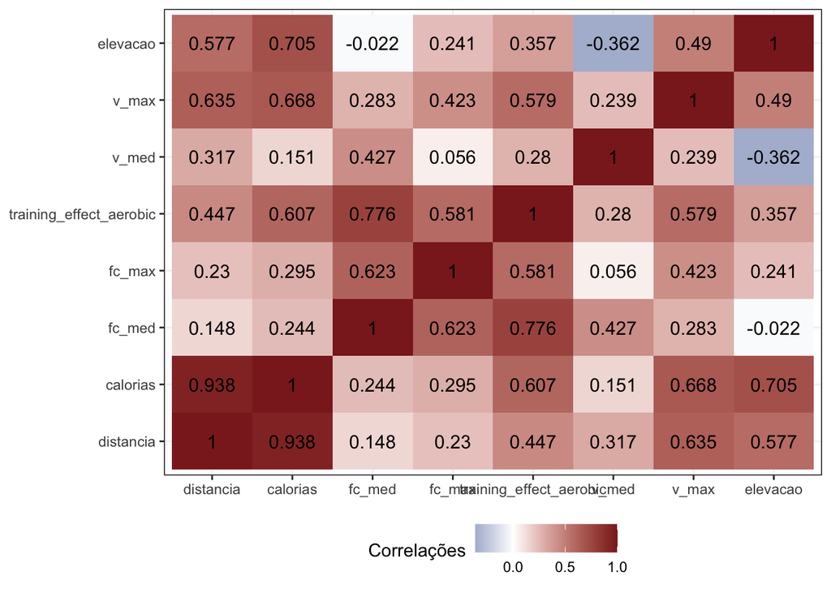

```r
# Construção de um heatmap

rho1 <- cor(cbind(dados_todos[2:3],dados_todos[5:10]))

rho1 %>%
  melt() %>%
  ggplot() +
  geom_tile(aes(x = Var1, y = Var2, fill = value)) +
  geom_text(aes(x = Var1, y = Var2, label = round(x = value, digits = 3)),
            size = 4) +
  labs(x = NULL,
       y = NULL,
       fill = "Correlações") +
  scale_fill_gradient2(low = "dodgerblue4",
                       mid = "white",
                       high = "brown4",
                       midpoint = 0) +
  theme(panel.background = element_rect("white"),
        panel.grid = element_line("grey95"),
        panel.border = element_rect(NA),
        legend.position = "bottom",
        axis.text.x = element_text(angle = 0))
```

Para visualizar os pares de variáveis mais significativas, vamos ordenar em um ranking, elencando das correlações mais fortes para as mais fracas.

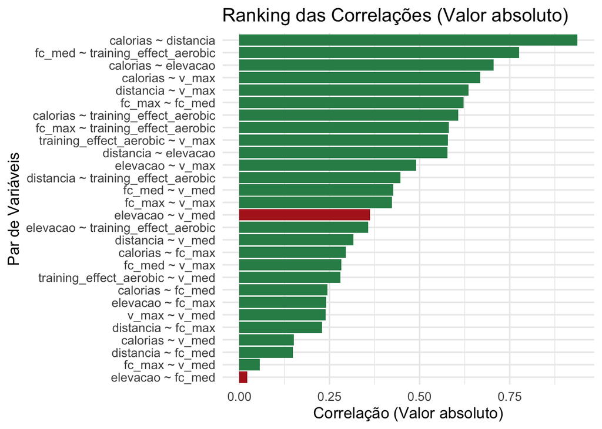

```r
# Transformando em formato longo com melt()
df_corr <- melt(rho1)

# Removendo a diagonal e ordenar pares únicos com valores absolutos
ranking_corr <- df_corr %>%
  filter(as.character(Var1) != as.character(Var2)) %>%
  mutate(
    Var1 = as.character(Var1),
    Var2 = as.character(Var2),
    abs_value = abs(value)
  ) %>%
  group_by(pair = paste(pmin(Var1, Var2), pmax(Var1, Var2), sep = " ~ ")) %>%
  summarise(
    correlacao = first(value),
    abs_cor = first(abs_value),
    .groups = "drop"
  ) %>%
  arrange(desc(abs_cor))

# Visualizando em gráfico de barras

ggplot(ranking_corr, aes(x = reorder(pair, abs_cor), y = abs_cor, fill = correlacao > 0)) +
  geom_col(show.legend = FALSE) +
  coord_flip() +
  labs(
    title = "Ranking das Correlações (Valor absoluto)",
    x = "Par de Variáveis",
    y = "Correlação (Valor absoluto)"
  ) +
  scale_fill_manual(values = c("TRUE" = "#2E8B57", "FALSE" = "#B22222")) +  # Verde para positiva, vermelho para negativa
  theme_minimal(base_size = 13)
```

Algumas observações pertinentes:

- Quanto maior a distância percorrida, mais calorias são gastas, sendo que a elevação do percurso também influencia no gasto calórico.
- Um treino de maior intensidade, com maior aerobic training effect, resulta em maior gastos calóricos e, parte desses treinos, aparentemente são em maiores distâncias, maior frequência cardíaca média, mas nem sempre são treinos de maiore elevação.
- A elevação não tem correlação com a frequência cardíaca média, provavelmente devido à descida na sequência, em que não há esforço relevante. Porém, há uma pequena correlação com a frequência cardíaca máxima, uma vez que subidas demandam maior capacidade aeróbica.
- As únicas variáveis que sao inversamente proporcionais de forma mais evidente é elevação e velocidade média, uma vez que quando há mais subidas a velocidade tende a ser reduzida.

Conclusões:

- Para queimar mais calorias, a distância percorrida deve ser maior. Porém, treinos mais intensos e/ou de subidas, possuem uma correlação significativa com gasto calórico, reforçando o conceito de High Intensity Interval Training (HIIT), amplamente difundido em treinos em geral.
- O training effect aerobic é maior em maiores distâncias, ainda que a correlação entre distância e frequência cardíaca média seja baixa. Provavelmente, isso ocorre devido treinos longos serem focados em Zona 2, com frequência cardíaca mais baixa e constante para sustentar longos períodos de tempo. Ainda sim, esses treinos são mais exaustivos devido às distâncias e tempo pedalando.
- A correlação significativa entre training effect aerobic e frequência cardíaca média ocorre provavelmente devido à treinos mais curtos e intensos, indicando que há ganho aeróbico nesse tipo de exercício.

Vamos explorar essas conclusões de forma visual

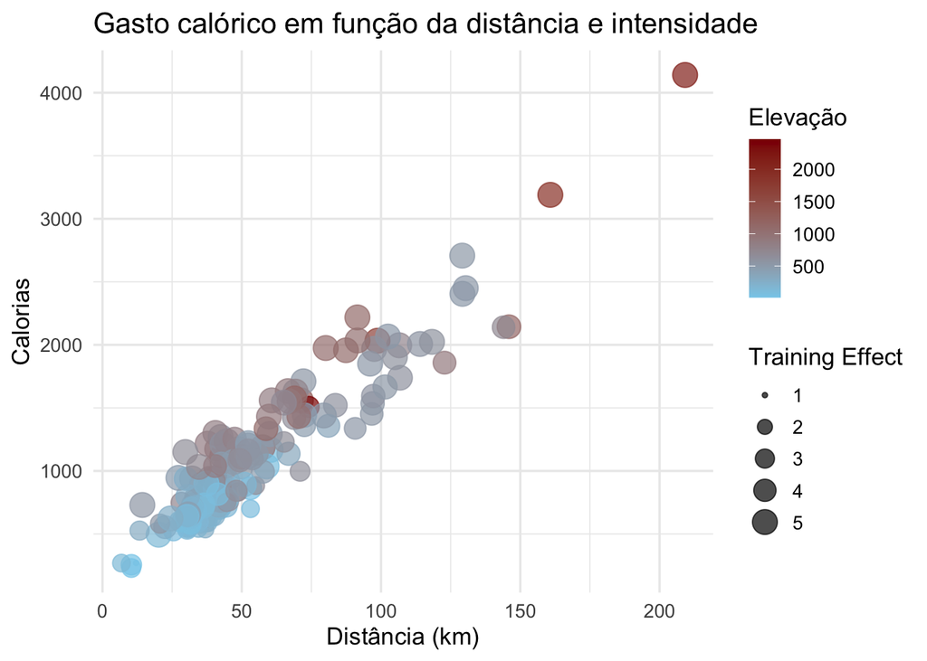

```r
ggplot(dados_todos, aes(x = distancia, y = calorias, color = elevacao, size = training_effect_aerobic)) +
  geom_point(alpha = 0.7) +
  scale_color_gradient(low = "skyblue", high = "darkred") +
  labs(
    title = "Gasto calórico em função da distância e intensidade",
    x = "Distância (km)", y = "Calorias",
    color = "Elevação", size = "Training Effect"
  ) +
  theme_minimal(base_size = 13)
```

Por esse gráfico, podemos perceber treinos de igual intensidade no canto esquerdo inferior, porém, com mesma distância e maior subida, o gasto calórico é maior. Da mesma forma, treinos de igual intensidade na faixa de 100km possuem gastos calóricos maior com maior elevação e ligeira menor distância do que treinos mais planos.

**Como será que essa sensacao de esforco muda com o aumento do FTP?**

Para ter uma melhoria ideia, vamos criar indicadores para eficiência energética.

- calorias/km: calorias é uma medida de trabalho realizado. quanto menos calorias eu gasto por km rodado, mais eficiente está a pedalada, ou seja, vou mais longe com menor esforço. Como a subida também infleuncia nessa distância, o ganho de elevação será transformado em km equivalente. Segundo a bibliografica, a cada 100mm de subida equivale à 1km plano, ao comparar os esforços.
- calorias/min: indica uma intensidade relativa do esforço (potência)
- training effect aerobic/min: densidade de estímulo do treino

Primeiro, vamos transformar o tempo de pedal em minutos.

```r
x <- unclass(dados_todos['tempo_pedal'])
df1 <- data.frame(x)

df1$hour_component <- as.numeric(format(df1$tempo_pedal,'%H'))
df1$min_component <- as.numeric(format(df1$tempo_pedal,'%M'))
df1$sec_component <- as.numeric(format(df1$tempo_pedal,'%S'))

df1$minutos <- df1$hour_component*60 + df1$min_component + df1$sec_component/60

dados_todos <- cbind(dados_todos,df1$minutos)
dados_todos <- rename(dados_todos, 'tempo_min' = 'df1$minutos')
```

Vamos calcular os novos indicadores

```r
# Calorias/km equivalente
dados_todos$cal_km_eq <- dados_todos$calorias / (dados_todos$distancia +
                                                   dados_todos$elevacao/100)

#Calorias/km
dados_todos$cal_km <- dados_todos$calorias / dados_todos$distancia

#Calorias/min
dados_todos$cal_min <- dados_todos$calorias / dados_todos$tempo_min

#Training Effect Aerobic/min
dados_todos$te_min <- dados_todos$training_effect_aerobic /
   dados_todos$tempo_min

# Elevação / km
dados_todos$eleva_km <- dados_todos$elevacao / (dados_todos$distancia*1000)
```

Agora vamos verificar como as cal/km equivalente se comportam ao longo do tempo

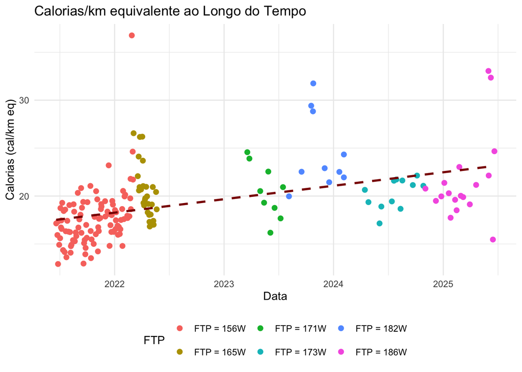

```r
g1 <- ggplot(dados_todos, aes(x = Data, y = cal_km_eq, color = as.factor(periodo))) +
  geom_point(size = 2) +
  geom_smooth(method = 'lm', se = FALSE, color = "darkred", linetype = "dashed", size = 1) +
  labs(title = "Calorias/km equivalente ao Longo do Tempo",
       x = "Data", y = "Calorias (cal/km eq)", color = "FTP") +
  theme_minimal() +
  theme(legend.position = "bottom")

g1
```

Há um aumento em calorias / km equivalente a medida que o FTP aumenta, sendo que essa diferença é mais significativa aparentemente entre FTPs de 156 e 165W e 171 a 186W.

Isso sugere que o trabalho necessario para andar os mesmos km é superior quando há um aumento de FTP. Para verificar essa questao, vamos ver como o esforco relativo cal/min se comporta ao longo do tempo.

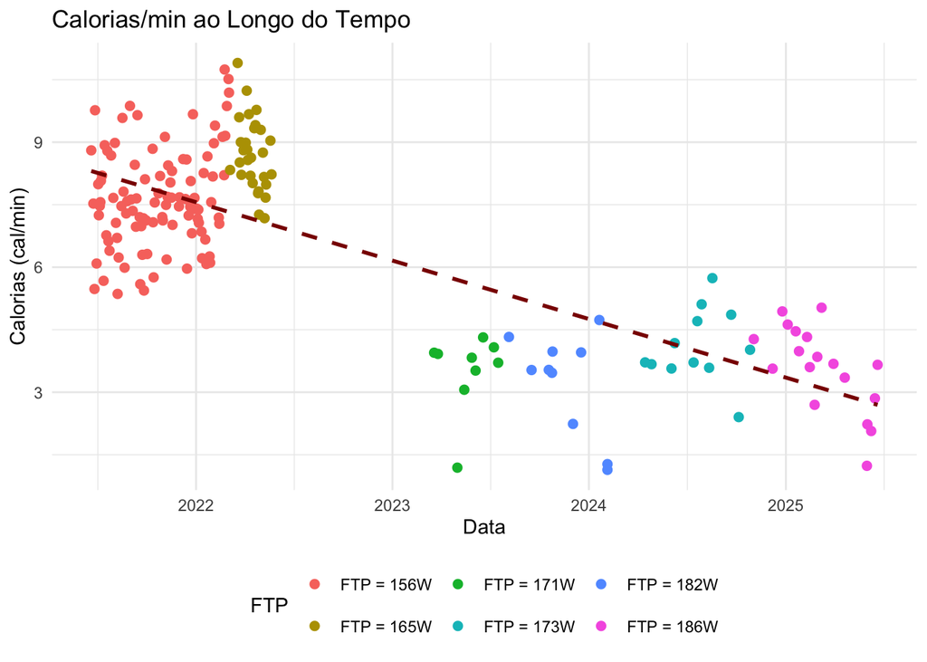

```r
g2 <- ggplot(dados_todos, aes(x = Data, y = cal_min, color = as.factor(periodo))) +
  geom_point(size = 2) +
  geom_smooth(method = 'lm', se = FALSE, color = "darkred", linetype = "dashed", size = 1) +
  labs(title = "Calorias/min ao Longo do Tempo",
       x = "Data", y = "Calorias (cal/min)", color = "FTP") +
  theme_minimal() +
  theme(legend.position = "bottom")

g2
```

Observa-se que há uma redução brusca no esforço relativo, mantendo, aparentemente, segregação dos grupos na análise anterior: FTP de 156 a 165W e FTP de 171 a 186W.

Esse resultado é curioso, visto que, em teoria, o esforço por km aumentou. Uma hipótese é que a análise de calorias/km equivalente não é adequada, provavelmente devido às subidas. Vamos visualizar melhor a elevação e distância separadamente ao longo do tempo.

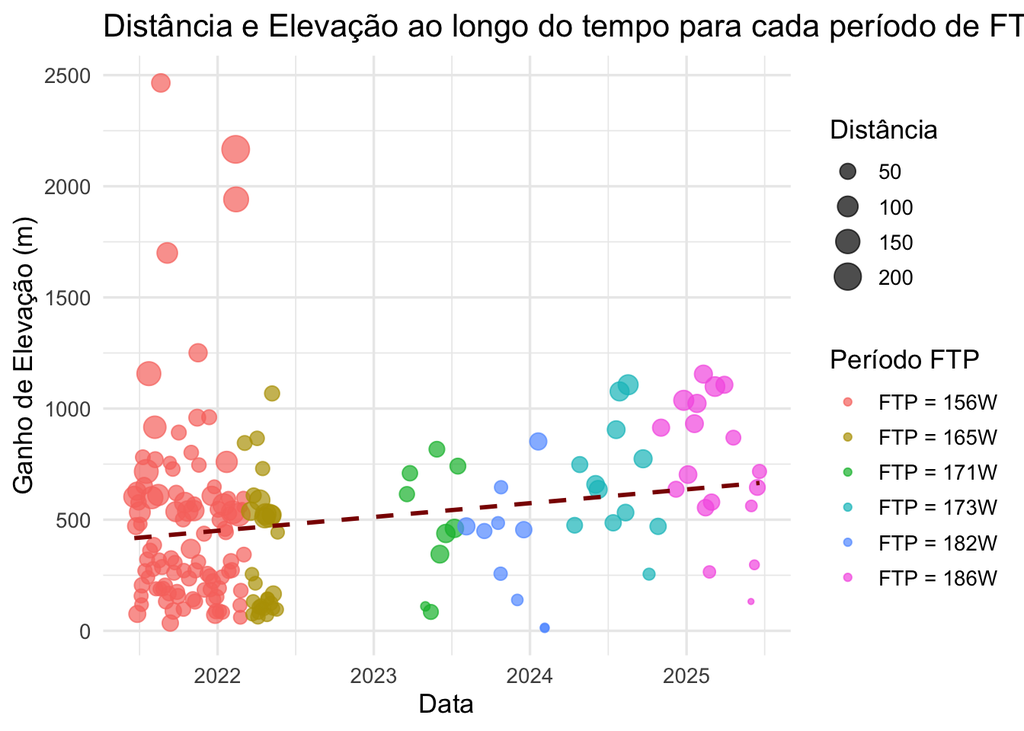

```r
ggplot(dados_todos, aes(x = Data, y = elevacao, color = periodo, size = distancia)) +
  geom_point(alpha = 0.7) +
  geom_smooth(method = 'lm', se = FALSE, color = "darkred", linetype = "dashed", size = 1) +
  labs(
    title = "Distância e Elevação ao longo do tempo para cada período de FTP",
    x = "Data", y = "Ganho de Elevação (m)",
    color = "Período FTP", size = "Distância"
  ) +
  theme_minimal(base_size = 13)
```

Realmente há uma tendência dos treinos possuírem maior elevação e distância ligeiramente menor com o passar do tempo. Essa observação faz sentido, uma vez que me mudei de Santos para JF e BH, locais com mais montanhas. Em Santos, os pedais de subida eram realizados normalmentes em morros dentro da cidade, com alto ganho de elevação e baixa quilometragem. Há alguns outliers devido momentos em que morava em Santos e pedalei em MG e pedais extremamente longos, com elevação maiores.

Com isso, conclui-se que não é possível avaliar a eficiência do pedal com o indicador calorias / km equivalente sozinho. Há diversos fatores que podem tornar uma subida com esforço variado, como o percentual de inclinação, a velocidade e condições climáticas (vento e temperatura, por exemplo). A conversão assumida de que cada 100m de subida equivale a 1km no plano não é válida.

Vamos visualizar como a inclinação média se alterou ao longo do tempo para entender se realmente o esforço pode ter variado devido relevo do terreno.

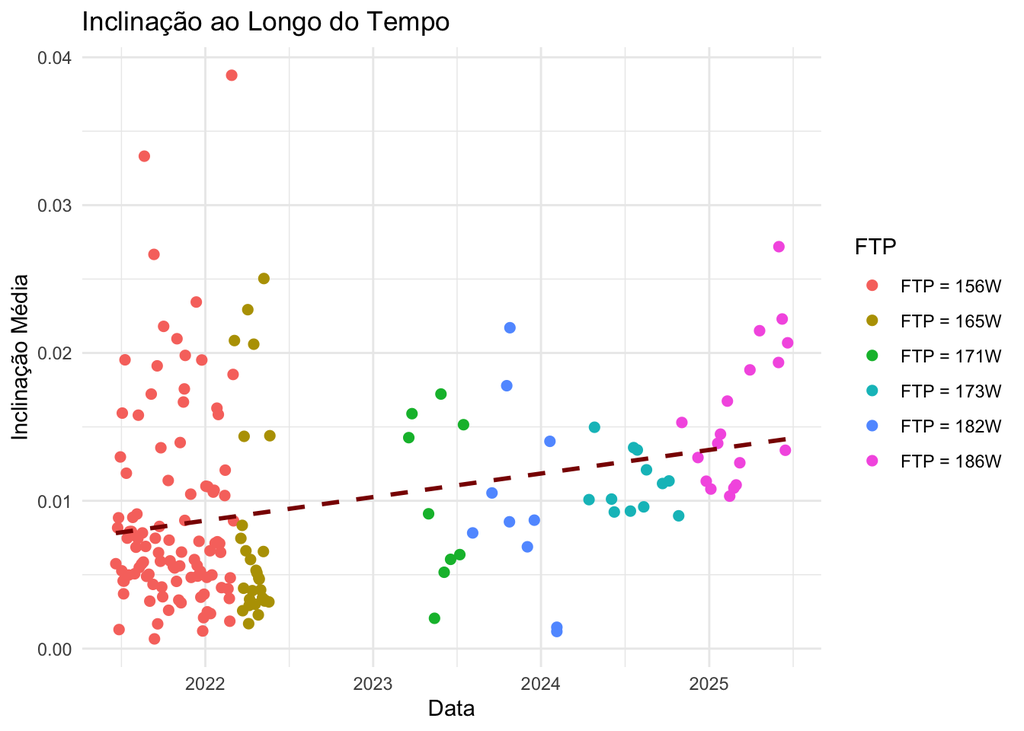

```r
ggplot(dados_todos, aes(x = Data, y = eleva_km, color = as.factor(periodo))) +
  geom_point(size = 2) +
  geom_smooth(method = 'lm', se = FALSE, color = "darkred", linetype = "dashed", size = 1) +
  labs(title = "Inclinação ao Longo do Tempo",
       x = "Data", y = "Inclinação Média", color = "FTP") +
  theme_minimal()
```

É possível confirmar a hipótese do aumento da inclinação média, ou seja, presença de subidas.

Visualizando os dois gráficos em uma página.

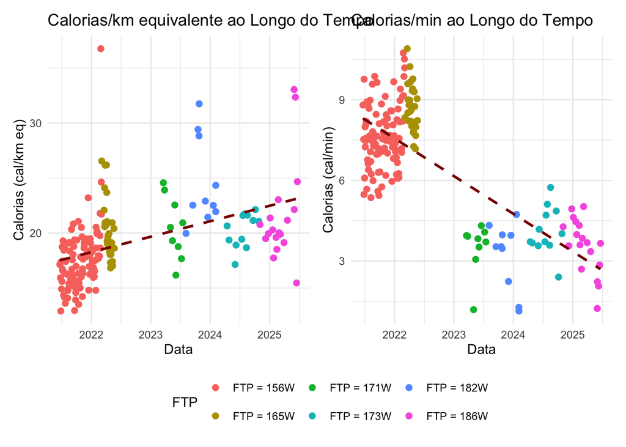

```r
(g1 + g2) + plot_layout(guides = "collect") & theme(legend.position = "bottom")
```